# Lab 8

Kent Codding

2023-11-10

# install dependencies

```r
library(glmmTMB)
library(performance)
library(magrittr)
```

# Step 1

```r
df <- read.csv("RCW_nests.csv")
```

## remove observations

```r
cluster.counts <- table(df$Cluster)
viable.clusters <- subset(cluster.counts, cluster.counts >= 5) #subset the table to only include clusters with 5 or more observations
df <- subset(df, df$Cluster %in% names(viable.clusters)) #subset df to only include clusters within the subsetted table
df <- subset(df, df$Adults != 6) #remove observations where 6 adults exist
```

# Step 2

```r
y <- cbind(df$hatched_eggs, df$failed_eggs)
```

## GLM

```r
mod.glm <- glm(y ~ df$Constructor + df$Adults + df$Adults * df$Constructor + df$Year,
      family = "binomial")
summary(mod.glm)
```

```
##
## Call:
## glm(formula = y ~ df$Constructor + df$Adults + df$Adults * df$Constructor +
##     df$Year, family = "binomial")
##
## Deviance Residuals:
##     Min       1Q   Median       3Q      Max
## -3.4073  -0.5843   0.1208   1.3119   1.9557
##
## Coefficients:
##                               Estimate Std. Error z value Pr(>|z|)
## (Intercept)                 -22.017345  23.759345  -0.927   0.3541
## df$ConstructorRCW            -0.116218   0.348645  -0.333   0.7389
## df$Adults                     0.189500   0.091891   2.062   0.0392 *
## df$Year                       0.011099   0.011852   0.936   0.3490
## df$ConstructorRCW:df$Adults   0.006446   0.115042   0.056   0.9553
## ---
## Signif. codes:  0 '***' 0.001 '**' 0.01 '*' 0.05 '.' 0.1 ' ' 1
##
## (Dispersion parameter for binomial family taken to be 1)
##
##     Null deviance: 865.10  on 630  degrees of freedom
## Residual deviance: 851.36  on 626  degrees of freedom
## AIC: 1569.4
##
## Number of Fisher Scoring iterations: 4
```

## GLMM with random intercept for Cluster

```r
mod.glmm1 <- glmmTMB(y ~ df$Constructor + df$Adults + df$Adults * df$Constructor + df$Year + (1|df$Cluster),
              family = "binomial")
summary(mod.glmm1)
```

```
##  Family: binomial  ( logit )
## Formula:
## y ~ df$Constructor + df$Adults + df$Adults * df$Constructor +
##     df$Year + (1 | df$Cluster)
##
##      AIC      BIC   logLik deviance df.resid
##   1567.0   1593.7   -777.5   1555.0      625
##
## Random effects:
##
## Conditional model:
##  Groups     Name        Variance Std.Dev.
##  df$Cluster (Intercept) 0.05683  0.2384
## Number of obs: 631, groups:  df$Cluster, 68
##
## Conditional model:
##                               Estimate Std. Error z value Pr(>|z|)
## (Intercept)                 -19.377531  24.437799  -0.793   0.4278
## df$ConstructorRCW            -0.157576   0.363135  -0.434   0.6643
## df$Adults                     0.172818   0.096492   1.791   0.0733 .
## df$Year                       0.009811   0.012191   0.805   0.4210
## df$ConstructorRCW:df$Adults   0.024481   0.119750   0.204   0.8380
## ---
## Signif. codes:  0 '***' 0.001 '**' 0.01 '*' 0.05 '.' 0.1 ' ' 1
```

## GLMM with random slope

referring to the effect of number of adults on hatching within each cluster

```r
mod.glmm2 <- glmmTMB(y ~ df$Constructor + df$Adults + df$Adults * df$Constructor + df$Year +(df$Adults|df$Cluster),
              family = "binomial")
summary(mod.glmm2)
```

```
##  Family: binomial  ( logit )
## Formula:
## y ~ df$Constructor + df$Adults + df$Adults * df$Constructor +
##     df$Year + (df$Adults | df$Cluster)
##
##      AIC      BIC   logLik deviance df.resid
##   1570.6   1606.2   -777.3   1554.6      623
##
## Random effects:
##
## Conditional model:
##  Groups     Name        Variance Std.Dev. Corr
##  df$Cluster (Intercept) 0.26829  0.5180
##             df$Adults   0.01813  0.1347   -0.90
## Number of obs: 631, groups:  df$Cluster, 68
##
## Conditional model:
##                              Estimate Std. Error z value Pr(>|z|)
## (Intercept)                 -20.19126   24.62691  -0.820   0.4123
## df$ConstructorRCW            -0.14630    0.37338  -0.392   0.6952
## df$Adults                     0.17082    0.09884   1.728   0.0839 .
## df$Year                       0.01022    0.01229   0.832   0.4054
## df$ConstructorRCW:df$Adults   0.02070    0.12291   0.168   0.8662
## ---
## Signif. codes:  0 '***' 0.001 '**' 0.01 '*' 0.05 '.' 0.1 ' ' 1
```

## Compare with AIC

```r
AIC(mod.glm, mod.glmm1, mod.glmm2)
```

```
##           df      AIC
## mod.glm    5 1569.415
## mod.glmm1  6 1567.008
## mod.glmm2  8 1570.610
```

the lowest AIC for glmm1, the glmm with a random intercept for cluster, is the best model according to this test.

# Step 3

##model selection on fixed terms

```r
summary(mod.glmm1)
```

```
##  Family: binomial  ( logit )
## Formula:
## y ~ df$Constructor + df$Adults + df$Adults * df$Constructor +
##     df$Year + (1 | df$Cluster)
##
##      AIC      BIC   logLik deviance df.resid
##   1567.0   1593.7   -777.5   1555.0      625
##
## Random effects:
##
## Conditional model:
##  Groups     Name        Variance Std.Dev.
##  df$Cluster (Intercept) 0.05683  0.2384
## Number of obs: 631, groups:  df$Cluster, 68
##
## Conditional model:
##                               Estimate Std. Error z value Pr(>|z|)
## (Intercept)                 -19.377531  24.437799  -0.793   0.4278
## df$ConstructorRCW            -0.157576   0.363135  -0.434   0.6643
## df$Adults                     0.172818   0.096492   1.791   0.0733 .
## df$Year                       0.009811   0.012191   0.805   0.4210
## df$ConstructorRCW:df$Adults   0.024481   0.119750   0.204   0.8380
## ---
## Signif. codes:  0 '***' 0.001 '**' 0.01 '*' 0.05 '.' 0.1 ' ' 1
```

```r
drop1(mod.glmm1, test = "Chisq")
```

```
## Single term deletions
##
## Model:
## y ~ df$Constructor + df$Adults + df$Adults * df$Constructor +
##     df$Year + (1 | df$Cluster)
##                          Df    AIC     LRT Pr(>Chi)
## <none>                      1567.0
## df$Year                   1 1565.7 0.64699   0.4212
## df$Constructor:df$Adults  1 1565.0 0.04179   0.8380
```

### refit dropping the interaction between constructor and adults

```r
mod.2 <- glmmTMB(y ~ df$Constructor + df$Adults + df$Year + (1|df$Cluster),
              family = "binomial") %>% suppressWarnings()
summary(mod.2)
```

```
##  Family: binomial  ( logit )
## Formula:          y ~ df$Constructor + df$Adults + df$Year + (1 | df$Cluster)
##
##      AIC      BIC   logLik deviance df.resid
##   1565.0   1587.3   -777.5   1555.0      626
##
## Random effects:
##
## Conditional model:
##  Groups     Name        Variance Std.Dev.
##  df$Cluster (Intercept) 0.05635  0.2374
## Number of obs: 631, groups:  df$Cluster, 68
##
## Conditional model:
##                     Estimate Std. Error z value Pr(>|z|)
## (Intercept)       -19.039543  24.376033  -0.781  0.43476
## df$ConstructorRCW  -0.086460   0.103929  -0.832  0.40546
## df$Adults           0.188615   0.057845   3.261  0.00111 **
## df$Year             0.009619   0.012152   0.792  0.42861
## ---
## Signif. codes:  0 '***' 0.001 '**' 0.01 '*' 0.05 '.' 0.1 ' ' 1
```

```r
drop1(mod.2, test = "Chisq") %>% suppressWarnings()
```

```
## Single term deletions
##
## Model:
## y ~ df$Constructor + df$Adults + df$Year + (1 | df$Cluster)
##                Df    AIC     LRT Pr(>Chi)
## <none>            1565.0
## df$Constructor  1 1563.7  0.6891 0.406478
## df$Adults       1 1573.7 10.6793 0.001083 **
## df$Year         1 1563.7  0.6259 0.428864
## ---
## Signif. codes:  0 '***' 0.001 '**' 0.01 '*' 0.05 '.' 0.1 ' ' 1
```

### refit dropping year

```r
mod.3 <- update(mod.2, .~. -df$Year) %>% suppressWarnings()
summary(mod.3)
```

```
##  Family: binomial  ( logit )
## Formula:          y ~ df$Constructor + df$Adults + (1 | df$Cluster)
##
##      AIC      BIC   logLik deviance df.resid
##   1563.7   1581.5   -777.8   1555.7      627
##
## Random effects:
##
## Conditional model:
##  Groups     Name        Variance Std.Dev.
##  df$Cluster (Intercept) 0.05803  0.2409
## Number of obs: 631, groups:  df$Cluster, 68
##
## Conditional model:
##                   Estimate Std. Error z value Pr(>|z|)
## (Intercept)        0.25516    0.18690   1.365  0.17217
## df$ConstructorRCW -0.07291    0.10276  -0.709  0.47802
## df$Adults          0.18637    0.05782   3.223  0.00127 **
## ---
## Signif. codes:  0 '***' 0.001 '**' 0.01 '*' 0.05 '.' 0.1 ' ' 1
```

```r
drop1(mod.3, test = "Chisq") %>% suppressWarnings()
```

```
## Single term deletions
##
## Model:
## y ~ df$Constructor + df$Adults + (1 | df$Cluster)
##                Df    AIC     LRT Pr(>Chi)
## <none>            1563.7
## df$Constructor  1 1562.2  0.5016 0.478808
## df$Adults       1 1572.1 10.4411 0.001232 **
## ---
## Signif. codes:  0 '***' 0.001 '**' 0.01 '*' 0.05 '.' 0.1 ' ' 1
```

### refit dropping constructor

```r
mod.4 <- update(mod.3, .~. -df$Constructor) %>% suppressWarnings()
summary(mod.4)
```

```
##  Family: binomial  ( logit )
## Formula:          y ~ df$Adults + (1 | df$Cluster)
##
##      AIC      BIC   logLik deviance df.resid
##   1562.2   1575.5   -778.1   1556.2      628
##
## Random effects:
##
## Conditional model:
##  Groups     Name        Variance Std.Dev.
##  df$Cluster (Intercept) 0.06035  0.2457
## Number of obs: 631, groups:  df$Cluster, 68
##
## Conditional model:
##             Estimate Std. Error z value Pr(>|z|)
## (Intercept)  0.21469    0.17821   1.205  0.22834
## df$Adults    0.18591    0.05792   3.210  0.00133 **
## ---
## Signif. codes:  0 '***' 0.001 '**' 0.01 '*' 0.05 '.' 0.1 ' ' 1
```

### Final interpretation

According to drop1 model selection with a chi square test, number of adults in the breeding group is the most important and only significant variable that determines the probability that an egg will successfully hatch. The positive sign for the estimate indicates that the number of Adults in the breeding group correlates with the number of eggs hatched, suggesting that more hands… or bird feet in this case… make for better work in regards to hatching chicks!

# Step 4

## overdispersion?

```r
check_overdispersion(mod.4) %>% suppressWarnings()
```

```
## # Overdispersion test
##
##        dispersion ratio =   1.001
##   Pearson's Chi-Squared = 628.463
##                 p-value =   0.487
```

```
## No overdispersion detected.
```

## nonindependence?

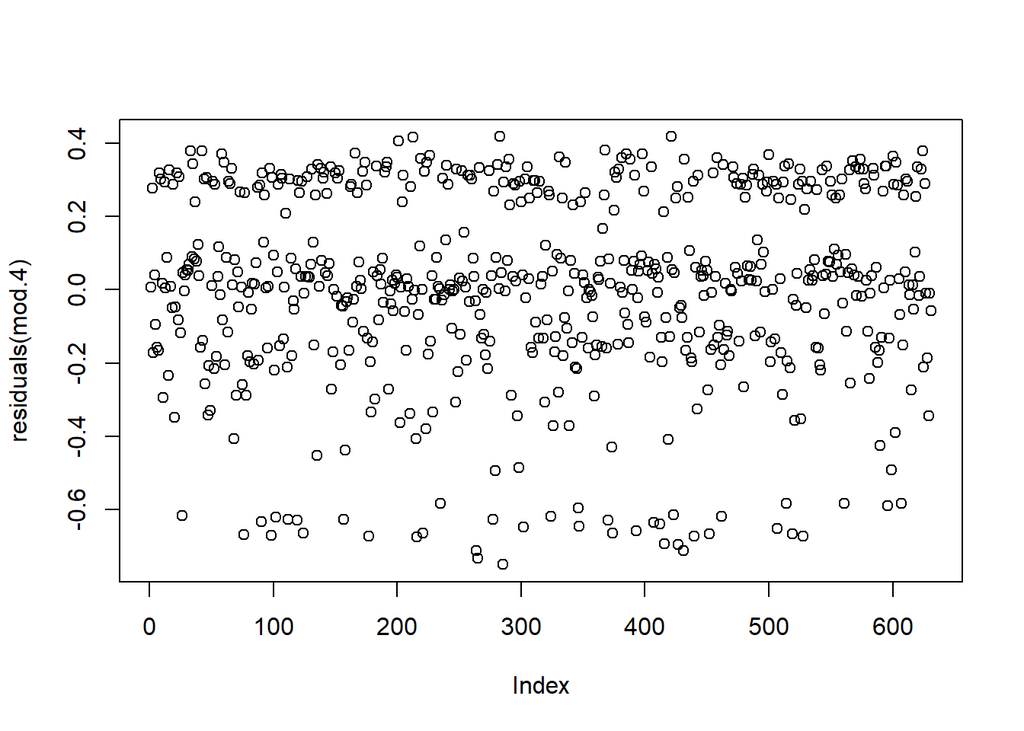

```r
plot(residuals(mod.4))
```

## random effect normally distributed

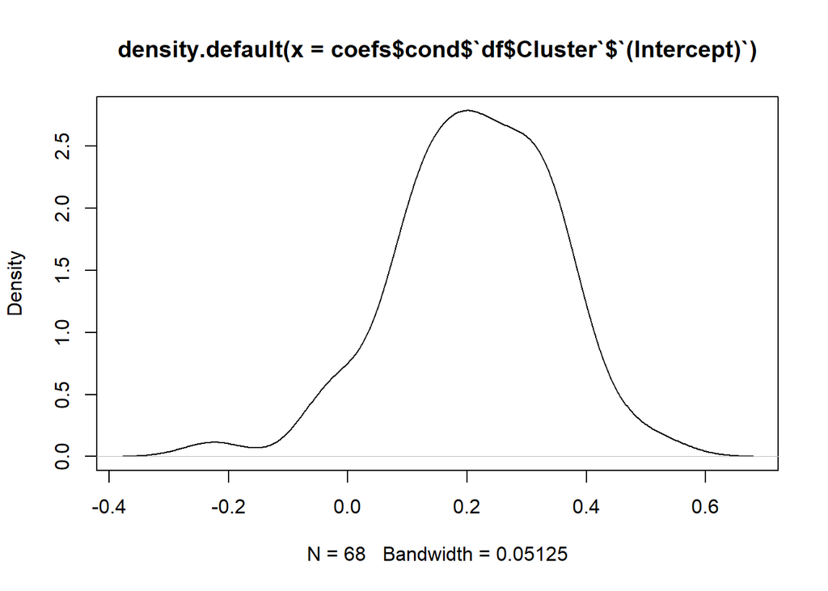

```r
coefs <- coefficients(mod.4)
plot(density(coefs$cond$`df$Cluster`$`(Intercept)`))
```

Visually, the random effects of the intercept are drawn from a normal distribution.

## explained variance of hatching success

```r
r2_nakagawa(mod.4) %>% suppressWarnings()
```

```
## # R2 for Mixed Models
##
##   Conditional R2: 0.025
##      Marginal R2: 0.007
```

only 2.5 percent of variance is explained by the entire model. Additionally, the fixed effects (marginal R2) only explain less than 1 percent of the variance. Thus, the random effects explain 0.025 - 0.007 = 0.018 of the variance.

## Plot

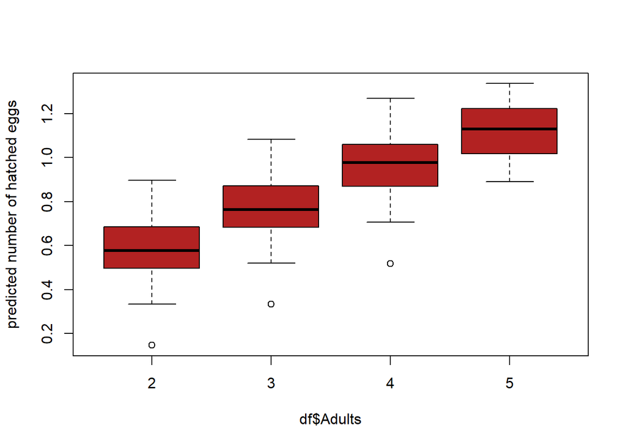

```r
y.pred <- predict(mod.4)

boxplot(y.pred ~ df$Adults,
        ylab = "predicted number of hatched eggs",
        col = "firebrick")
```

# Step 5

The data suggests that the type of Constructor (RCW vs Human) does not impact the number of hatchlings. Thus, managers should continue creating artificial, human-made cavity boxes in suitable trees. However, given limited resources, managers should focus on creating cavity boxes in suitable trees within areas already populated by large RCW families as the number of adults in each breeding group may affect the probability of eggs hatching.